# Risk Factor Analysis

## Outcome Variable

**Outcome Variable:** ever_stunted

## Predictor Variables

**Intervention Variable:** gagebrth

**Adjustment Set:**

- arm
- W_mage
- meducyrs
- feducyrs
- hhwealth_quart
- single
- brthmon
- W_parity
- delta_W_mage
- delta_meducyrs
- delta_feducyrs
- delta_hhwealth_quart
- delta_single
- delta_brthmon
- delta_W_parity

## Stratifying Variables

The analysis was stratified on these variable(s):

- agecat
- studyid
- country

## Data Summary

| agecat | studyid | country | gagebrth | ever_stunted | n_cell | n |
| --- | --- | --- | --- | --- | --- | --- |
| 0-24 months (no birth st.) | CMC-V-BCS-2002 | INDIA | Full or late term | 0 | 18 | 278 |
| 0-24 months (no birth st.) | CMC-V-BCS-2002 | INDIA | Full or late term | 1 | 164 | 278 |
| 0-24 months (no birth st.) | CMC-V-BCS-2002 | INDIA | Preterm | 0 | 3 | 278 |
| 0-24 months (no birth st.) | CMC-V-BCS-2002 | INDIA | Preterm | 1 | 30 | 278 |
| 0-24 months (no birth st.) | CMC-V-BCS-2002 | INDIA | Early term | 0 | 7 | 278 |
| 0-24 months (no birth st.) | CMC-V-BCS-2002 | INDIA | Early term | 1 | 56 | 278 |
| 0-24 months (no birth st.) | COHORTS | GUATEMALA | Full or late term | 0 | 94 | 694 |
| 0-24 months (no birth st.) | COHORTS | GUATEMALA | Full or late term | 1 | 303 | 694 |
| 0-24 months (no birth st.) | COHORTS | GUATEMALA | Preterm | 0 | 23 | 694 |
| 0-24 months (no birth st.) | COHORTS | GUATEMALA | Preterm | 1 | 79 | 694 |
| 0-24 months (no birth st.) | COHORTS | GUATEMALA | Early term | 0 | 41 | 694 |
| 0-24 months (no birth st.) | COHORTS | GUATEMALA | Early term | 1 | 154 | 694 |
| 0-24 months (no birth st.) | COHORTS | INDIA | Full or late term | 0 | 395 | 1238 |
| 0-24 months (no birth st.) | COHORTS | INDIA | Full or late term | 1 | 160 | 1238 |
| 0-24 months (no birth st.) | COHORTS | INDIA | Preterm | 0 | 181 | 1238 |
| 0-24 months (no birth st.) | COHORTS | INDIA | Preterm | 1 | 88 | 1238 |
| 0-24 months (no birth st.) | COHORTS | INDIA | Early term | 0 | 290 | 1238 |
| 0-24 months (no birth st.) | COHORTS | INDIA | Early term | 1 | 124 | 1238 |
| 0-24 months (no birth st.) | COHORTS | PHILIPPINES | Full or late term | 0 | 395 | 2846 |
| 0-24 months (no birth st.) | COHORTS | PHILIPPINES | Full or late term | 1 | 735 | 2846 |
| 0-24 months (no birth st.) | COHORTS | PHILIPPINES | Preterm | 0 | 185 | 2846 |
| 0-24 months (no birth st.) | COHORTS | PHILIPPINES | Preterm | 1 | 380 | 2846 |
| 0-24 months (no birth st.) | COHORTS | PHILIPPINES | Early term | 0 | 370 | 2846 |
| 0-24 months (no birth st.) | COHORTS | PHILIPPINES | Early term | 1 | 781 | 2846 |
| 0-24 months (no birth st.) | IRC | INDIA | Full or late term | 0 | 95 | 341 |
| 0-24 months (no birth st.) | IRC | INDIA | Full or late term | 1 | 126 | 341 |
| 0-24 months (no birth st.) | IRC | INDIA | Preterm | 0 | 9 | 341 |
| 0-24 months (no birth st.) | IRC | INDIA | Preterm | 1 | 23 | 341 |
| 0-24 months (no birth st.) | IRC | INDIA | Early term | 0 | 34 | 341 |
| 0-24 months (no birth st.) | IRC | INDIA | Early term | 1 | 54 | 341 |

[output cut: 150 more lines]

The following strata were considered:

- agecat: 0-24 months (no birth st.), studyid: CMC-V-BCS-2002, country: INDIA
- agecat: 0-24 months (no birth st.), studyid: COHORTS, country: GUATEMALA
- agecat: 0-24 months (no birth st.), studyid: COHORTS, country: INDIA
- agecat: 0-24 months (no birth st.), studyid: COHORTS, country: PHILIPPINES
- agecat: 0-24 months (no birth st.), studyid: IRC, country: INDIA
- agecat: 0-24 months (no birth st.), studyid: JiVitA-3, country: BANGLADESH
- agecat: 0-24 months (no birth st.), studyid: Keneba, country: GAMBIA
- agecat: 0-24 months (no birth st.), studyid: NIH-Crypto, country: BANGLADESH
- agecat: 0-24 months (no birth st.), studyid: PROBIT, country: BELARUS
- agecat: 0-24 months (no birth st.), studyid: TanzaniaChild2, country: TANZANIA, UNITED REPUBLIC OF
- agecat: 0-6 months (no birth st.), studyid: CMC-V-BCS-2002, country: INDIA
- agecat: 0-6 months (no birth st.), studyid: COHORTS, country: GUATEMALA
- agecat: 0-6 months (no birth st.), studyid: COHORTS, country: INDIA
- agecat: 0-6 months (no birth st.), studyid: COHORTS, country: PHILIPPINES
- agecat: 0-6 months (no birth st.), studyid: IRC, country: INDIA
- agecat: 0-6 months (no birth st.), studyid: JiVitA-3, country: BANGLADESH
- agecat: 0-6 months (no birth st.), studyid: Keneba, country: GAMBIA
- agecat: 0-6 months (no birth st.), studyid: NIH-Crypto, country: BANGLADESH
- agecat: 0-6 months (no birth st.), studyid: PROBIT, country: BELARUS
- agecat: 0-6 months (no birth st.), studyid: TanzaniaChild2, country: TANZANIA, UNITED REPUBLIC OF
- agecat: 6-24 months, studyid: CMC-V-BCS-2002, country: INDIA
- agecat: 6-24 months, studyid: COHORTS, country: GUATEMALA
- agecat: 6-24 months, studyid: COHORTS, country: INDIA
- agecat: 6-24 months, studyid: COHORTS, country: PHILIPPINES
- agecat: 6-24 months, studyid: IRC, country: INDIA
- agecat: 6-24 months, studyid: JiVitA-3, country: BANGLADESH
- agecat: 6-24 months, studyid: Keneba, country: GAMBIA
- agecat: 6-24 months, studyid: NIH-Crypto, country: BANGLADESH
- agecat: 6-24 months, studyid: PROBIT, country: BELARUS
- agecat: 6-24 months, studyid: TanzaniaChild2, country: TANZANIA, UNITED REPUBLIC OF

### Dropped Strata

Some strata were dropped due to rare outcomes:

- agecat: 0-24 months (no birth st.), studyid: CMC-V-BCS-2002, country: INDIA
- agecat: 6-24 months, studyid: CMC-V-BCS-2002, country: INDIA

## Methods Detail

We’re interested in the causal parameters $E[Y_a]$ for all values of $a \in \mathcal{A}$. These parameters represent the mean outcome if, possibly contrary to fact, we intervened to set all units to have $A=a$. Under the randomization and positivity assumptions, these are identified by the statistical parameters $\psi_a=E_W[E_{Y|A,W}(Y|A=a,W)]$. In addition, we’re interested in the mean of $Y$, $E[Y]$ under no intervention (the observed mean). We will estimate these parameters by using SuperLearner to fit the relevant likelihood factors – $E_{Y|A,W}(Y|A=a,W)$ and $p(A=a|W)$, and then updating our likelihood fit using a joint TMLE.

For unadjusted analyses ($W=\{\}$), initial likelihoods were estimated using Lrnr_glm to estimate the simple $E(Y|A)$ and Lrnr_mean to estimate $p(A)$. For adjusted analyses, a small library containing Lrnr_glmnet, Lrnr_xgboost, and Lrnr_mean was used.

Having estimated these parameters, we will then use the delta method to estimate relative risks and attributable risks relative to a prespecified baseline level of $A$.

# Results Detail

## Results Plots

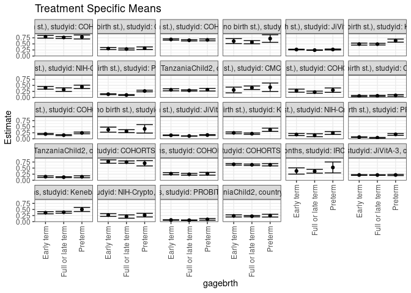

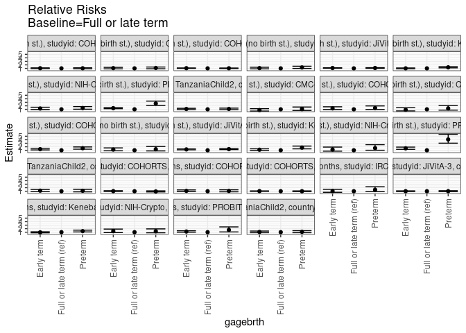

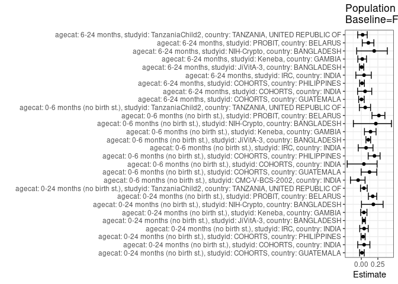

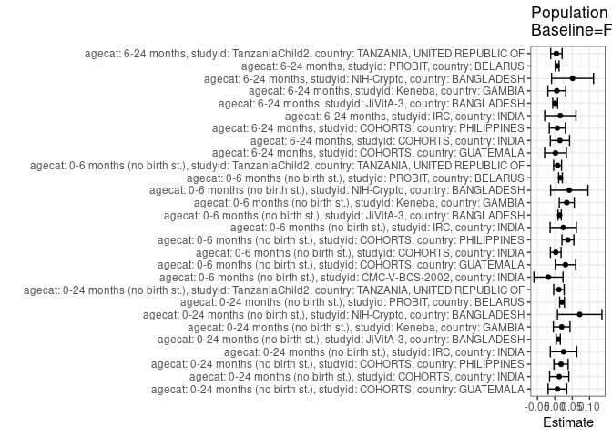

## Results Table

### Parameter: TSM

| agecat | studyid | country | intervention_level | baseline_level | estimate | ci_lower | ci_upper |
| --- | --- | --- | --- | --- | --- | --- | --- |
| 0-24 months (no birth st.) | COHORTS | GUATEMALA | Full or late term | NA | 0.7648292 | 0.7229143 | 0.8067441 |
| 0-24 months (no birth st.) | COHORTS | GUATEMALA | Preterm | NA | 0.7840160 | 0.7024601 | 0.8655719 |
| 0-24 months (no birth st.) | COHORTS | GUATEMALA | Early term | NA | 0.7932459 | 0.7358458 | 0.8506461 |
| 0-24 months (no birth st.) | COHORTS | INDIA | Full or late term | NA | 0.2878858 | 0.2508570 | 0.3249146 |
| 0-24 months (no birth st.) | COHORTS | INDIA | Preterm | NA | 0.3202373 | 0.2646190 | 0.3758556 |
| 0-24 months (no birth st.) | COHORTS | INDIA | Early term | NA | 0.3073546 | 0.2634174 | 0.3512917 |
| 0-24 months (no birth st.) | COHORTS | PHILIPPINES | Full or late term | NA | 0.6484108 | 0.6213662 | 0.6754554 |
| 0-24 months (no birth st.) | COHORTS | PHILIPPINES | Preterm | NA | 0.6642016 | 0.6268859 | 0.7015173 |
| 0-24 months (no birth st.) | COHORTS | PHILIPPINES | Early term | NA | 0.6825079 | 0.6561147 | 0.7089010 |
| 0-24 months (no birth st.) | IRC | INDIA | Full or late term | NA | 0.5701357 | 0.5047709 | 0.6355006 |
| 0-24 months (no birth st.) | IRC | INDIA | Preterm | NA | 0.7187500 | 0.5627423 | 0.8747577 |
| 0-24 months (no birth st.) | IRC | INDIA | Early term | NA | 0.6136364 | 0.5117542 | 0.7155185 |
| 0-24 months (no birth st.) | JiVitA-3 | BANGLADESH | Full or late term | NA | 0.2435016 | 0.2336319 | 0.2533714 |
| 0-24 months (no birth st.) | JiVitA-3 | BANGLADESH | Preterm | NA | 0.2691281 | 0.2494207 | 0.2888355 |
| 0-24 months (no birth st.) | JiVitA-3 | BANGLADESH | Early term | NA | 0.2679968 | 0.2538275 | 0.2821661 |
| 0-24 months (no birth st.) | Keneba | GAMBIA | Full or late term | NA | 0.4894525 | 0.4550038 | 0.5239012 |
| 0-24 months (no birth st.) | Keneba | GAMBIA | Preterm | NA | 0.6344403 | 0.5708851 | 0.6979956 |
| 0-24 months (no birth st.) | Keneba | GAMBIA | Early term | NA | 0.4907650 | 0.4493613 | 0.5321686 |
| 0-24 months (no birth st.) | NIH-Crypto | BANGLADESH | Full or late term | NA | 0.3219017 | 0.2496015 | 0.3942019 |
| 0-24 months (no birth st.) | NIH-Crypto | BANGLADESH | Preterm | NA | 0.4362424 | 0.3673380 | 0.5051468 |
| 0-24 months (no birth st.) | NIH-Crypto | BANGLADESH | Early term | NA | 0.3959891 | 0.3402630 | 0.4517153 |
| 0-24 months (no birth st.) | PROBIT | BELARUS | Full or late term | NA | 0.0998052 | 0.0819601 | 0.1176503 |
| 0-24 months (no birth st.) | PROBIT | BELARUS | Preterm | NA | 0.2651855 | 0.2307055 | 0.2996656 |
| 0-24 months (no birth st.) | PROBIT | BELARUS | Early term | NA | 0.1329604 | 0.1152855 | 0.1506353 |
| 0-24 months (no birth st.) | TanzaniaChild2 | TANZANIA, UNITED REPUBLIC OF | Full or late term | NA | 0.2861655 | 0.2617719 | 0.3105592 |
| 0-24 months (no birth st.) | TanzaniaChild2 | TANZANIA, UNITED REPUBLIC OF | Preterm | NA | 0.3182946 | 0.2651350 | 0.3714541 |
| 0-24 months (no birth st.) | TanzaniaChild2 | TANZANIA, UNITED REPUBLIC OF | Early term | NA | 0.3141014 | 0.2723418 | 0.3558610 |
| 0-6 months (no birth st.) | CMC-V-BCS-2002 | INDIA | Full or late term | NA | 0.3979112 | 0.3258037 | 0.4700187 |
| 0-6 months (no birth st.) | CMC-V-BCS-2002 | INDIA | Preterm | NA | 0.4195389 | 0.2462286 | 0.5928492 |
| 0-6 months (no birth st.) | CMC-V-BCS-2002 | INDIA | Early term | NA | 0.3073353 | 0.1887103 | 0.4259604 |

[output cut: 54 more lines]

### Parameter: E(Y)

| agecat | studyid | country | intervention_level | baseline_level | estimate | ci_lower | ci_upper |
| --- | --- | --- | --- | --- | --- | --- | --- |
| 0-24 months (no birth st.) | COHORTS | GUATEMALA | NA | NA | 0.7723343 | 0.7411143 | 0.8035543 |
| 0-24 months (no birth st.) | COHORTS | INDIA | NA | NA | 0.3004847 | 0.2749357 | 0.3260336 |
| 0-24 months (no birth st.) | COHORTS | PHILIPPINES | NA | NA | 0.6661982 | 0.6488700 | 0.6835264 |
| 0-24 months (no birth st.) | IRC | INDIA | NA | NA | 0.5953079 | 0.5431354 | 0.6474804 |
| 0-24 months (no birth st.) | JiVitA-3 | BANGLADESH | NA | NA | 0.2533685 | 0.2454041 | 0.2613329 |
| 0-24 months (no birth st.) | Keneba | GAMBIA | NA | NA | 0.5091714 | 0.4845214 | 0.5338214 |
| 0-24 months (no birth st.) | NIH-Crypto | BANGLADESH | NA | NA | 0.3935681 | 0.3560687 | 0.4310676 |
| 0-24 months (no birth st.) | PROBIT | BELARUS | NA | NA | 0.1205488 | 0.1047261 | 0.1363714 |
| 0-24 months (no birth st.) | TanzaniaChild2 | TANZANIA, UNITED REPUBLIC OF | NA | NA | 0.2979534 | 0.2783922 | 0.3175146 |
| 0-6 months (no birth st.) | CMC-V-BCS-2002 | INDIA | NA | NA | 0.3795620 | 0.3219972 | 0.4371269 |
| 0-6 months (no birth st.) | COHORTS | GUATEMALA | NA | NA | 0.2481315 | 0.2153770 | 0.2808861 |
| 0-6 months (no birth st.) | COHORTS | INDIA | NA | NA | 0.0687398 | 0.0545482 | 0.0829313 |
| 0-6 months (no birth st.) | COHORTS | PHILIPPINES | NA | NA | 0.1897400 | 0.1753322 | 0.2041478 |
| 0-6 months (no birth st.) | IRC | INDIA | NA | NA | 0.3401760 | 0.2898173 | 0.3905347 |
| 0-6 months (no birth st.) | JiVitA-3 | BANGLADESH | NA | NA | 0.1315668 | 0.1257634 | 0.1373703 |
| 0-6 months (no birth st.) | Keneba | GAMBIA | NA | NA | 0.2466667 | 0.2248446 | 0.2684887 |
| 0-6 months (no birth st.) | NIH-Crypto | BANGLADESH | NA | NA | 0.1898928 | 0.1597870 | 0.2199986 |
| 0-6 months (no birth st.) | PROBIT | BELARUS | NA | NA | 0.0614448 | 0.0507274 | 0.0721623 |
| 0-6 months (no birth st.) | TanzaniaChild2 | TANZANIA, UNITED REPUBLIC OF | NA | NA | 0.1346978 | 0.1200961 | 0.1492994 |
| 6-24 months | COHORTS | GUATEMALA | NA | NA | 0.7490347 | 0.7116615 | 0.7864080 |
| 6-24 months | COHORTS | INDIA | NA | NA | 0.2598214 | 0.2341270 | 0.2855158 |
| 6-24 months | COHORTS | PHILIPPINES | NA | NA | 0.6444867 | 0.6240287 | 0.6649447 |
| 6-24 months | IRC | INDIA | NA | NA | 0.3866667 | 0.3228931 | 0.4504402 |
| 6-24 months | JiVitA-3 | BANGLADESH | NA | NA | 0.2163549 | 0.2067486 | 0.2259611 |
| 6-24 months | Keneba | GAMBIA | NA | NA | 0.3917012 | 0.3641291 | 0.4192734 |
| 6-24 months | NIH-Crypto | BANGLADESH | NA | NA | 0.2628459 | 0.2244546 | 0.3012371 |
| 6-24 months | PROBIT | BELARUS | NA | NA | 0.0642659 | 0.0526827 | 0.0758490 |
| 6-24 months | TanzaniaChild2 | TANZANIA, UNITED REPUBLIC OF | NA | NA | 0.2274536 | 0.2062895 | 0.2486177 |

### Parameter: RR

| agecat | studyid | country | intervention_level | baseline_level | estimate | ci_lower | ci_upper |
| --- | --- | --- | --- | --- | --- | --- | --- |
| 0-24 months (no birth st.) | COHORTS | GUATEMALA | Full or late term | Full or late term | 1.0000000 | 1.0000000 | 1.000000 |
| 0-24 months (no birth st.) | COHORTS | GUATEMALA | Preterm | Full or late term | 1.0250864 | 0.9113610 | 1.153003 |
| 0-24 months (no birth st.) | COHORTS | GUATEMALA | Early term | Full or late term | 1.0371543 | 0.9470541 | 1.135826 |
| 0-24 months (no birth st.) | COHORTS | INDIA | Full or late term | Full or late term | 1.0000000 | 1.0000000 | 1.000000 |
| 0-24 months (no birth st.) | COHORTS | INDIA | Preterm | Full or late term | 1.1123761 | 0.8975903 | 1.378558 |
| 0-24 months (no birth st.) | COHORTS | INDIA | Early term | Full or late term | 1.0676267 | 0.8825561 | 1.291506 |
| 0-24 months (no birth st.) | COHORTS | PHILIPPINES | Full or late term | Full or late term | 1.0000000 | 1.0000000 | 1.000000 |
| 0-24 months (no birth st.) | COHORTS | PHILIPPINES | Preterm | Full or late term | 1.0243530 | 0.9559980 | 1.097595 |
| 0-24 months (no birth st.) | COHORTS | PHILIPPINES | Early term | Full or late term | 1.0525856 | 0.9953795 | 1.113079 |
| 0-24 months (no birth st.) | IRC | INDIA | Full or late term | Full or late term | 1.0000000 | 1.0000000 | 1.000000 |
| 0-24 months (no birth st.) | IRC | INDIA | Preterm | Full or late term | 1.2606647 | 0.9862620 | 1.611413 |
| 0-24 months (no birth st.) | IRC | INDIA | Early term | Full or late term | 1.0762987 | 0.8796426 | 1.316920 |
| 0-24 months (no birth st.) | JiVitA-3 | BANGLADESH | Full or late term | Full or late term | 1.0000000 | 1.0000000 | 1.000000 |
| 0-24 months (no birth st.) | JiVitA-3 | BANGLADESH | Preterm | Full or late term | 1.1052415 | 1.0185040 | 1.199366 |
| 0-24 months (no birth st.) | JiVitA-3 | BANGLADESH | Early term | Full or late term | 1.1005955 | 1.0335880 | 1.171947 |
| 0-24 months (no birth st.) | Keneba | GAMBIA | Full or late term | Full or late term | 1.0000000 | 1.0000000 | 1.000000 |
| 0-24 months (no birth st.) | Keneba | GAMBIA | Preterm | Full or late term | 1.2962245 | 1.1474117 | 1.464338 |
| 0-24 months (no birth st.) | Keneba | GAMBIA | Early term | Full or late term | 1.0026815 | 0.8985211 | 1.118917 |
| 0-24 months (no birth st.) | NIH-Crypto | BANGLADESH | Full or late term | Full or late term | 1.0000000 | 1.0000000 | 1.000000 |
| 0-24 months (no birth st.) | NIH-Crypto | BANGLADESH | Preterm | Full or late term | 1.3552036 | 1.0314088 | 1.780649 |
| 0-24 months (no birth st.) | NIH-Crypto | BANGLADESH | Early term | Full or late term | 1.2301553 | 0.9458676 | 1.599888 |
| 0-24 months (no birth st.) | PROBIT | BELARUS | Full or late term | Full or late term | 1.0000000 | 1.0000000 | 1.000000 |
| 0-24 months (no birth st.) | PROBIT | BELARUS | Preterm | Full or late term | 2.6570319 | 2.1170922 | 3.334677 |
| 0-24 months (no birth st.) | PROBIT | BELARUS | Early term | Full or late term | 1.3321995 | 1.1829064 | 1.500335 |
| 0-24 months (no birth st.) | TanzaniaChild2 | TANZANIA, UNITED REPUBLIC OF | Full or late term | Full or late term | 1.0000000 | 1.0000000 | 1.000000 |
| 0-24 months (no birth st.) | TanzaniaChild2 | TANZANIA, UNITED REPUBLIC OF | Preterm | Full or late term | 1.1122743 | 0.9220566 | 1.341733 |
| 0-24 months (no birth st.) | TanzaniaChild2 | TANZANIA, UNITED REPUBLIC OF | Early term | Full or late term | 1.0976212 | 0.9372132 | 1.285484 |
| 0-6 months (no birth st.) | CMC-V-BCS-2002 | INDIA | Full or late term | Full or late term | 1.0000000 | 1.0000000 | 1.000000 |
| 0-6 months (no birth st.) | CMC-V-BCS-2002 | INDIA | Preterm | Full or late term | 1.0543531 | 0.6714632 | 1.655579 |
| 0-6 months (no birth st.) | CMC-V-BCS-2002 | INDIA | Early term | Full or late term | 0.7723717 | 0.5041988 | 1.183180 |

[output cut: 54 more lines]

### Parameter: PAR

| agecat | studyid | country | intervention_level | baseline_level | estimate | ci_lower | ci_upper |
| --- | --- | --- | --- | --- | --- | --- | --- |
| 0-24 months (no birth st.) | COHORTS | GUATEMALA | Full or late term | NA | 0.0075051 | -0.0194808 | 0.0344909 |
| 0-24 months (no birth st.) | COHORTS | INDIA | Full or late term | NA | 0.0125988 | -0.0150372 | 0.0402349 |
| 0-24 months (no birth st.) | COHORTS | PHILIPPINES | Full or late term | NA | 0.0177873 | -0.0027226 | 0.0382973 |
| 0-24 months (no birth st.) | IRC | INDIA | Full or late term | NA | 0.0251722 | -0.0129918 | 0.0633362 |
| 0-24 months (no birth st.) | JiVitA-3 | BANGLADESH | Full or late term | NA | 0.0098669 | 0.0040018 | 0.0157319 |
| 0-24 months (no birth st.) | Keneba | GAMBIA | Full or late term | NA | 0.0197189 | -0.0042869 | 0.0437247 |
| 0-24 months (no birth st.) | NIH-Crypto | BANGLADESH | Full or late term | NA | 0.0716664 | 0.0077078 | 0.1356251 |
| 0-24 months (no birth st.) | PROBIT | BELARUS | Full or late term | NA | 0.0207436 | 0.0139564 | 0.0275308 |
| 0-24 months (no birth st.) | TanzaniaChild2 | TANZANIA, UNITED REPUBLIC OF | Full or late term | NA | 0.0117878 | -0.0033596 | 0.0269353 |
| 0-6 months (no birth st.) | CMC-V-BCS-2002 | INDIA | Full or late term | NA | -0.0183492 | -0.0602131 | 0.0235148 |
| 0-6 months (no birth st.) | COHORTS | GUATEMALA | Full or late term | NA | 0.0306306 | 0.0014077 | 0.0598534 |
| 0-6 months (no birth st.) | COHORTS | INDIA | Full or late term | NA | 0.0026426 | -0.0127472 | 0.0180324 |
| 0-6 months (no birth st.) | COHORTS | PHILIPPINES | Full or late term | NA | 0.0376641 | 0.0205151 | 0.0548132 |
| 0-6 months (no birth st.) | IRC | INDIA | Full or late term | NA | 0.0243297 | -0.0134665 | 0.0621260 |
| 0-6 months (no birth st.) | JiVitA-3 | BANGLADESH | Full or late term | NA | 0.0139009 | 0.0092246 | 0.0185773 |
| 0-6 months (no birth st.) | Keneba | GAMBIA | Full or late term | NA | 0.0343762 | 0.0127326 | 0.0560199 |
| 0-6 months (no birth st.) | NIH-Crypto | BANGLADESH | Full or late term | NA | 0.0416056 | -0.0121341 | 0.0953454 |
| 0-6 months (no birth st.) | PROBIT | BELARUS | Full or late term | NA | 0.0162938 | 0.0109553 | 0.0216322 |
| 0-6 months (no birth st.) | TanzaniaChild2 | TANZANIA, UNITED REPUBLIC OF | Full or late term | NA | 0.0079429 | -0.0034549 | 0.0193407 |
| 6-24 months | COHORTS | GUATEMALA | Full or late term | NA | 0.0019642 | -0.0293598 | 0.0332881 |
| 6-24 months | COHORTS | INDIA | Full or late term | NA | 0.0146869 | -0.0130686 | 0.0424425 |
| 6-24 months | COHORTS | PHILIPPINES | Full or late term | NA | 0.0072294 | -0.0159535 | 0.0304124 |
| 6-24 months | IRC | INDIA | Full or late term | NA | 0.0158057 | -0.0292126 | 0.0608240 |
| 6-24 months | JiVitA-3 | BANGLADESH | Full or late term | NA | 0.0010672 | -0.0059747 | 0.0081091 |
| 6-24 months | Keneba | GAMBIA | Full or late term | NA | 0.0057142 | -0.0199350 | 0.0313635 |
| 6-24 months | NIH-Crypto | BANGLADESH | Full or late term | NA | 0.0510604 | -0.0093550 | 0.1114757 |
| 6-24 months | PROBIT | BELARUS | Full or late term | NA | 0.0068319 | 0.0015894 | 0.0120744 |
| 6-24 months | TanzaniaChild2 | TANZANIA, UNITED REPUBLIC OF | Full or late term | NA | 0.0044703 | -0.0119211 | 0.0208616 |

### Parameter: PAF

| agecat | studyid | country | intervention_level | baseline_level | estimate | ci_lower | ci_upper |
| --- | --- | --- | --- | --- | --- | --- | --- |
| 0-24 months (no birth st.) | COHORTS | GUATEMALA | Full or late term | NA | 0.0097174 | -0.0258623 | 0.0440631 |
| 0-24 months (no birth st.) | COHORTS | INDIA | Full or late term | NA | 0.0419284 | -0.0545524 | 0.1295822 |
| 0-24 months (no birth st.) | COHORTS | PHILIPPINES | Full or late term | NA | 0.0266998 | -0.0045976 | 0.0570221 |
| 0-24 months (no birth st.) | IRC | INDIA | Full or late term | NA | 0.0422843 | -0.0242259 | 0.1044755 |
| 0-24 months (no birth st.) | JiVitA-3 | BANGLADESH | Full or late term | NA | 0.0389427 | 0.0154860 | 0.0618406 |
| 0-24 months (no birth st.) | Keneba | GAMBIA | Full or late term | NA | 0.0387275 | -0.0096385 | 0.0847765 |
| 0-24 months (no birth st.) | NIH-Crypto | BANGLADESH | Full or late term | NA | 0.1820941 | 0.0023750 | 0.3294373 |
| 0-24 months (no birth st.) | PROBIT | BELARUS | Full or late term | NA | 0.1720763 | 0.1068582 | 0.2325321 |
| 0-24 months (no birth st.) | TanzaniaChild2 | TANZANIA, UNITED REPUBLIC OF | Full or late term | NA | 0.0395627 | -0.0126365 | 0.0890711 |
| 0-6 months (no birth st.) | CMC-V-BCS-2002 | INDIA | Full or late term | NA | -0.0483430 | -0.1646950 | 0.0563855 |
| 0-6 months (no birth st.) | COHORTS | GUATEMALA | Full or late term | NA | 0.1234449 | -0.0020859 | 0.2332505 |
| 0-6 months (no birth st.) | COHORTS | INDIA | Full or late term | NA | 0.0384440 | -0.2134393 | 0.2380418 |
| 0-6 months (no birth st.) | COHORTS | PHILIPPINES | Full or late term | NA | 0.1985040 | 0.1036788 | 0.2832973 |
| 0-6 months (no birth st.) | IRC | INDIA | Full or late term | NA | 0.0715210 | -0.0465096 | 0.1762396 |
| 0-6 months (no birth st.) | JiVitA-3 | BANGLADESH | Full or late term | NA | 0.1056568 | 0.0695824 | 0.1403324 |
| 0-6 months (no birth st.) | Keneba | GAMBIA | Full or late term | NA | 0.1393631 | 0.0474226 | 0.2224298 |
| 0-6 months (no birth st.) | NIH-Crypto | BANGLADESH | Full or late term | NA | 0.2191007 | -0.1204739 | 0.4557626 |
| 0-6 months (no birth st.) | PROBIT | BELARUS | Full or late term | NA | 0.2651771 | 0.1611452 | 0.3563073 |
| 0-6 months (no birth st.) | TanzaniaChild2 | TANZANIA, UNITED REPUBLIC OF | Full or late term | NA | 0.0589685 | -0.0293950 | 0.1397469 |
| 6-24 months | COHORTS | GUATEMALA | Full or late term | NA | 0.0026222 | -0.0400870 | 0.0435777 |
| 6-24 months | COHORTS | INDIA | Full or late term | NA | 0.0565270 | -0.0565243 | 0.1574814 |
| 6-24 months | COHORTS | PHILIPPINES | Full or late term | NA | 0.0112174 | -0.0254193 | 0.0465451 |
| 6-24 months | IRC | INDIA | Full or late term | NA | 0.0408769 | -0.0829571 | 0.1505508 |
| 6-24 months | JiVitA-3 | BANGLADESH | Full or late term | NA | 0.0049327 | -0.0281720 | 0.0369715 |
| 6-24 months | Keneba | GAMBIA | Full or late term | NA | 0.0145883 | -0.0531199 | 0.0779433 |
| 6-24 months | NIH-Crypto | BANGLADESH | Full or late term | NA | 0.1942597 | -0.0703462 | 0.3934510 |
| 6-24 months | PROBIT | BELARUS | Full or late term | NA | 0.1063062 | 0.0143094 | 0.1897168 |
| 6-24 months | TanzaniaChild2 | TANZANIA, UNITED REPUBLIC OF | Full or late term | NA | 0.0196535 | -0.0551030 | 0.0891133 |